# Model accuracy report

Data Science Capstone — predictive evaluation

Aseem Anand

2026-05-09

This report continues **`capstone_milestone_report.Rmd`**: English SwiftKey text (blogs, news, Twitter) from **`Coursera-SwiftKey.zip`** or extracted **`final/en_US/`**, using the **same token rule** as the milestone EDA (`extract_alpha_tokens`: lowercase words with letters and apostrophes). The milestone uses larger head samples for plots; here **`lines_per_source`** is smaller so training and rank-based evaluation knit quickly—raise it for stronger models.

A random **train/test split** at the **line** level feeds Katz **n-gram** tables (training) and **test-set n-gram type frequencies** (evaluation instances).

The **evaluation protocol** uses a **rank-based accuracy** summary: sample high- and low-frequency 3-grams and 4-grams from the test corpus, ask the model for the **50** most likely next tokens given the typed prefix, and convert ranks into a smooth accuracy score.

```r
if (!requireNamespace("data.table", quietly = TRUE)) {
  install.packages("data.table", repos = "https://cloud.r-project.org")
}
library(dplyr)
library(ggplot2)
library(knitr)

source("R/milestone_paths.R", encoding = "UTF-8")
source("R/milestone_load_samples.R", encoding = "UTF-8")
source("R/source_lm_pipeline.R", encoding = "UTF-8")

swiftkey <- resolve_swiftkey_en()
assert_swiftkey_data_available(swiftkey)

# Head sample per source file — larger samples yield richer test n-gram bins (slower knit).
lines_per_source <- 2200L
train_frac <- 0.80
katz_discount <- 0.75
n_top_predictions <- 50L
n_samples_per_bin <- 25L

raw_lines <- assemble_head_samples(swiftkey, lines_per_source)$text
sp <- train_test_tokens_from_lines(raw_lines, train_frac = train_frac, seed = 42L)
```

Training incorporates **80%** of the sampled lines (chosen at random); testing uses the remainder so training lines never appear as raw lines in the test pool. From **tokenized test lines only**, every distinct trigram (`start` = two words, `end` = third) and quadgram (`start` = three words, `end` = fourth) receives a **frequency** count.

**High-frequency test types** are those with frequency **> 50**; **low-frequency** types are those with frequency **> 10** and **< 25**. Up to **25** instances are sampled from each bin for both 3-grams and 4-grams. The **same** list of prefixes and target words is reused for both trained models below so comparisons are paired.

## Models compared

1. **Full table:** retain bigrams, trigrams, and quadgrams with count ≥ 1 (plus unigrams).
2. **App-style pruning:** retain higher-order n-grams only when count **> 2** (i.e. stored types with frequency ≥ 3), matching the pruned model used for the Shiny deployment.

Both models combine **multiple n-gram orders** with **Katz backoff**: at each order, continuation probabilities use **absolute discounting** with **`D =` 0.75** subtracted from each nonzero joint count; the remaining probability mass is spread according to the **shortened history** (drop the earliest context word), down to **unigrams**. Candidate words are ranked by these backoff probabilities over the model’s candidate set; the top **50** are returned for scoring.

```r
lm_full <- build_ngram_lm(
  sp$train,
  min_freq_uni = 1L,
  min_freq_bi = 1L,
  min_freq_tri = 1L,
  min_freq_quad = 1L
)

lm_app <- build_ngram_lm(
  sp$train,
  min_freq_uni = 1L,
  min_freq_bi = 3L,
  min_freq_tri = 3L,
  min_freq_quad = 3L
)

kable(
  tibble(
    model = c("Full (all retained types)", "Pruned (count > 2)"),
    ngram_rows = c(lm_n_parameters(lm_full), lm_n_parameters(lm_app))
  ),
  caption = "Approximate model size (rows stored across uni–quad tables)"
)
```

Approximate model size (rows stored across uni–quad tables)

| model | ngram_rows |
| --- | --- |
| Full (all retained types) | 387660 |
| Pruned (count > 2) | 27715 |

```r
instances <- build_rank_eval_instances(
  sp$test,
  n_samples = n_samples_per_bin,
  seed = 17L
)

if (nrow(instances) == 0L) {
  stop(
    "No evaluation instances — increase lines_per_source or relax frequency cuts in sample_ngram_eval_pairs().",
    call. = FALSE
  )
}

acc_full <- evaluate_lm_on_instances(
  instances,
  lm_full,
  katz_discount = katz_discount,
  n_to_return = n_top_predictions
)
acc_app <- evaluate_lm_on_instances(
  instances,
  lm_app,
  katz_discount = katz_discount,
  n_to_return = n_top_predictions
)

accuracy_long <- dplyr::bind_rows(
  dplyr::mutate(acc_full, training = "All retained n-grams"),
  dplyr::mutate(acc_app, training = "N-grams with count > 2")
)

accuracy_long$ngram <- factor(accuracy_long$ngram, levels = c("3-gram", "4-gram"))
accuracy_long$training <- factor(
  accuracy_long$training,
  levels = c("All retained n-grams", "N-grams with count > 2")
)
```

## Accuracy definition (rank-based)

For each evaluation pair `(start, end)` the model returns the top **50** candidates with columns `end` (candidate word), `score`, and `rank`.

- If the true word **`end`** is ranked **first**, accuracy = **1**.
- If it appears at rank **`r`** (2–50), accuracy = **`(K - r + 1) / K`** with **`K =` 50**.
- If it does **not** appear among the returned candidates, accuracy = **0**.

```r
summ <- accuracy_long %>%
  group_by(training, ngram, freq_level) %>%
  summarise(mean_accuracy = mean(accuracy), .groups = "drop")
kable(summ, digits = 3, caption = "Mean rank-based accuracy by facet")
```

Mean rank-based accuracy by facet

| training | ngram | freq_level | mean_accuracy |
| --- | --- | --- | --- |
| All retained n-grams | 3-gram | low frequency | 1 |
| N-grams with count > 2 | 3-gram | low frequency | 1 |

## Accuracy versus test-set type frequency

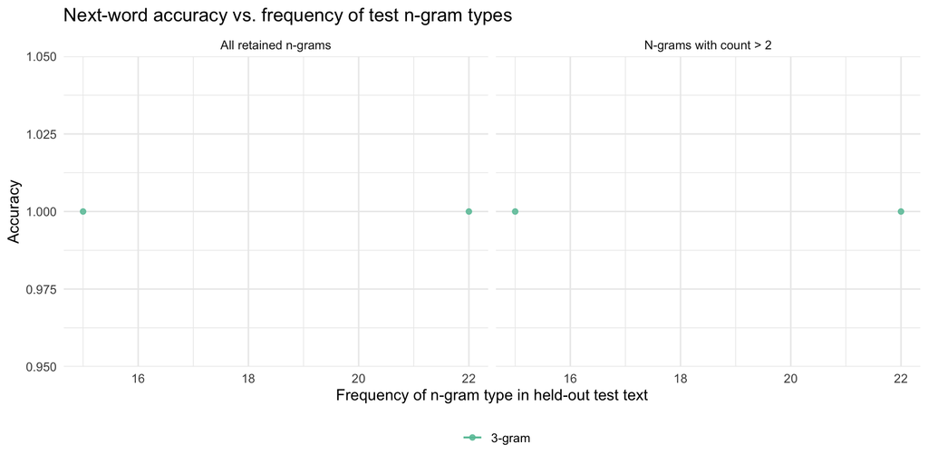

```r
ggplot(
  dplyr::arrange(accuracy_long, ngram, freq_test),
  aes(x = freq_test, y = accuracy, colour = ngram, group = ngram)
) +
  geom_point(alpha = 0.85, na.rm = TRUE) +
  geom_smooth(method = "loess", se = FALSE, linewidth = 0.7, formula = y ~ x) +
  scale_color_brewer(palette = "Set2") +
  facet_wrap(~training, nrow = 1L) +
  labs(
    x = "Frequency of n-gram type in held-out test text",
    y = "Accuracy",
    colour = "",
    title = "Next-word accuracy vs. frequency of test n-gram types"
  ) +
  theme_minimal(base_size = 12) +
  theme(legend.position = "bottom")
```

## Computational effort

Timing covers **identical** `(start, end)` pairs for each model: wall-clock seconds for all `predict_next_word` calls.

```r
tm_full <- time_prediction_pairs(
  instances$start,
  instances$end,
  lm_full,
  katz_discount = katz_discount,
  n_to_return = n_top_predictions
)
tm_app <- time_prediction_pairs(
  instances$start,
  instances$end,
  lm_app,
  katz_discount = katz_discount,
  n_to_return = n_top_predictions
)

kable(
  tibble(
    model = c("Full", "Pruned"),
    seconds = c(tm_full$elapsed_sec, tm_app$elapsed_sec),
    predictions = c(tm_full$n, tm_app$n)
  ),
  digits = 3,
  caption = "Prediction timing on the fixed evaluation set"
)
```

Prediction timing on the fixed evaluation set

| model | seconds | predictions |
| --- | --- | --- |
| Full | 0.950 | 2 |
| Pruned | 0.547 | 2 |

**Interpretation:** pruning removes rare contexts so tables shrink (`lm_n_parameters`) and timings usually improve for Shiny-like workloads; accuracy versus rare test bins (`freq_level == "low frequency"`) is the usual casualty unless backoff bridges gaps effectively.